# Metodología de Engle-Granger

Oscar García Cervantes - Taller de economía cuantitativa VI

miércoles 08 de junio, 2022

# 1. Paqueterias

```r
library(tseries)
library(readxl)
library(tidyverse)
library(ggfortify)
library(aTSA)
library(dyn)
library(lmtest)
library(car)
library(strucchange)
```

# 2. Datos

Para esta sesión utilizaremos las series del Producto Interno Bruto (PIB) total, y el PIB manufacturero publicadas por el Instituto Nacional de Estadística y Geografía (INEGI).

```r
Base <- read_excel("Base.xls")
str(Base)
```

```
## tibble [117 x 3] (S3: tbl_df/tbl/data.frame)
##  $ Periodo                                        : chr [1:117] "1993/01" "1993/02" "1993/03" "1993/04" ...
##  $ PIB total (millones de pesos a precios de 2013): num [1:117] 10066637 10093399 10195673 10329475 10436751 ...
##  $ PIB manufacturero                              : num [1:117] 1700483 1676932 1672136 1681928 1695252 ...
```

Le damos a las series formato de serie de tiempo, creamos la variable PIB no manufacturero y obtenemos los logaritmos de las series.

```r
PIB <- ts(Base$`PIB total (millones de pesos a precios de 2013)`, start = c(1993, 1), frequency = 4)
PIBMan <- ts(Base$`PIB manufacturero`, start = c(1993, 1), frequency = 4)
PIB_No_Man <- PIB - PIBMan
lPIB <- log(PIB)
lPIBMan <- log(PIBMan)
lPIB_No_Man <- log(PIB_No_Man)
```

# 3. Visualización de los datos

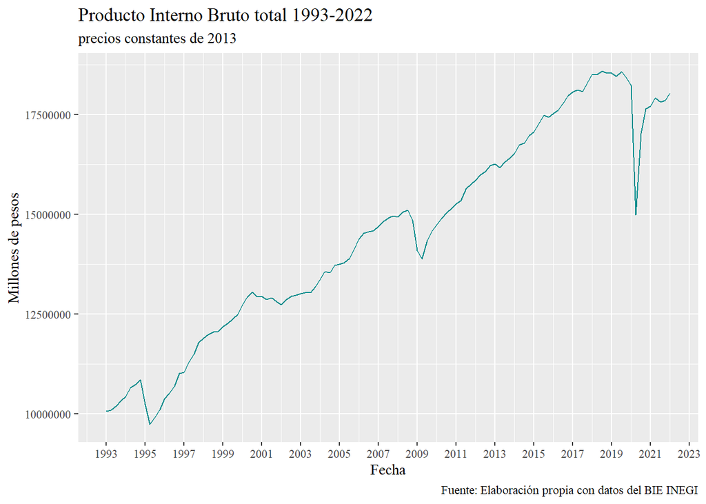

```r
ggplot2::autoplot(PIB, ts.colour = "cyan4") +
     labs(title = "Producto Interno Bruto total 1993-2022",
          subtitle = "precios constantes de 2013",
          x = "Fecha",
          y = "Millones de pesos",
          caption = "Fuente: Elaboración propia con datos del BIE INEGI") +
     theme_gray(base_family = "serif") +
     scale_x_date(date_breaks = "2 year", date_labels = "%Y")
```

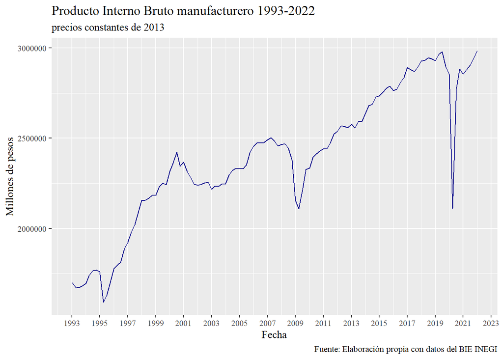

```r
ggplot2::autoplot(PIBMan, ts.colour = "darkblue") +
     labs(title = "Producto Interno Bruto manufacturero 1993-2022",
          subtitle = "precios constantes de 2013",
          x = "Fecha",
          y = "Millones de pesos",
          caption = "Fuente: Elaboración propia con datos del BIE INEGI") +
     theme_gray(base_family = "serif") +
     scale_x_date(date_breaks = "2 year", date_labels = "%Y")
```

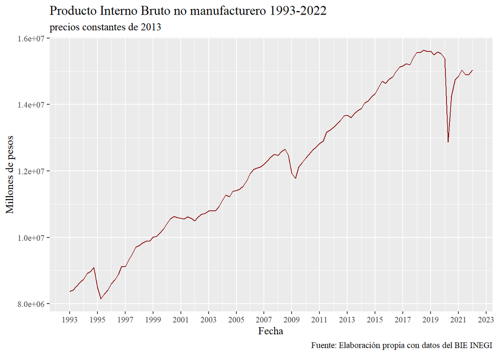

```r
ggplot2::autoplot(PIB_No_Man, ts.colour = "darkred") +
     labs(title = "Producto Interno Bruto no manufacturero 1993-2022",
          subtitle = "precios constantes de 2013",
          x = "Fecha",
          y = "Millones de pesos",
          caption = "Fuente: Elaboración propia con datos del BIE INEGI") +
     theme_gray(base_family = "serif") +
     scale_x_date(date_breaks = "2 year", date_labels = "%Y")
```

# 4. Modelo econométrico

El modelo a estimar es la primera Ley de Kaldor la cual indica que el sector manufacturero es el motor de la economía.
$$PIB\_No\_Man = \beta_0+\beta_1PIBMan+\epsilon_i$$

El primer paso es realizar las pruebas de raices unitarias a las series.

```r
aTSA::adf.test(lPIB)
```

```
## Augmented Dickey-Fuller Test
## alternative: stationary
##
## Type 1: no drift no trend
##      lag  ADF p.value
## [1,]   0 2.10    0.99
## [2,]   1 2.35    0.99
## [3,]   2 2.50    0.99
## [4,]   3 2.59    0.99
## [5,]   4 2.66    0.99
## Type 2: with drift no trend
##      lag   ADF p.value
## [1,]   0 -1.40   0.557
## [2,]   1 -1.43   0.546
## [3,]   2 -1.43   0.546
## [4,]   3 -1.40   0.555
## [5,]   4 -1.40   0.558
## Type 3: with drift and trend
##      lag   ADF p.value
## [1,]   0 -3.11   0.114
## [2,]   1 -2.75   0.264
## [3,]   2 -2.48   0.372
## [4,]   3 -2.27   0.460
## [5,]   4 -2.08   0.537
## ----
## Note: in fact, p.value = 0.01 means p.value <= 0.01
```

```r
aTSA::adf.test(lPIBMan)
```

```
## Augmented Dickey-Fuller Test
## alternative: stationary
##
## Type 1: no drift no trend
##      lag  ADF p.value
## [1,]   0 1.19   0.937
## [2,]   1 1.56   0.969
## [3,]   2 1.74   0.979
## [4,]   3 1.89   0.984
## [5,]   4 1.97   0.988
## Type 2: with drift no trend
##      lag   ADF p.value
## [1,]   0 -1.81   0.402
## [2,]   1 -1.71   0.442
## [3,]   2 -1.74   0.430
## [4,]   3 -1.76   0.423
## [5,]   4 -1.78   0.415
## Type 3: with drift and trend
##      lag   ADF p.value
## [1,]   0 -3.63  0.0331
## [2,]   1 -3.00  0.1614
## [3,]   2 -2.82  0.2347
## [4,]   3 -2.66  0.2987
## [5,]   4 -2.57  0.3373
## ----
## Note: in fact, p.value = 0.01 means p.value <= 0.01
```

```r
aTSA::adf.test(lPIB_No_Man)
```

```
## Augmented Dickey-Fuller Test
## alternative: stationary
##
## Type 1: no drift no trend
##      lag  ADF p.value
## [1,]   0 2.34    0.99
## [2,]   1 2.51    0.99
## [3,]   2 2.65    0.99
## [4,]   3 2.72    0.99
## [5,]   4 2.76    0.99
## Type 2: with drift no trend
##      lag   ADF p.value
## [1,]   0 -1.37   0.565
## [2,]   1 -1.39   0.558
## [3,]   2 -1.38   0.564
## [4,]   3 -1.34   0.578
## [5,]   4 -1.32   0.584
## Type 3: with drift and trend
##      lag   ADF p.value
## [1,]   0 -2.83   0.230
## [2,]   1 -2.55   0.343
## [3,]   2 -2.25   0.466
## [4,]   3 -2.04   0.555
## [5,]   4 -1.85   0.635
## ----
## Note: in fact, p.value = 0.01 means p.value <= 0.01
```

Las series presentan raices unitarias en niveles por lo que procedemos a estimar las primeras diferencias y realizar nuevamente la prueba ADF.

```r
d1_lPIB <- diff(lPIB, lag = 4, differences = 1)
d1_lPIBMan <- diff(lPIBMan, lag = 4, differences = 1)
d1_lPIB_NMan <- diff(lPIB_No_Man, lag = 4, differences = 1)

aTSA::adf.test(d1_lPIB)
```

```
## Augmented Dickey-Fuller Test
## alternative: stationary
##
## Type 1: no drift no trend
##      lag   ADF p.value
## [1,]   0 -4.59  0.0100
## [2,]   1 -4.42  0.0100
## [3,]   2 -4.54  0.0100
## [4,]   3 -5.30  0.0100
## [5,]   4 -2.34  0.0209
## Type 2: with drift no trend
##      lag   ADF p.value
## [1,]   0 -5.12  0.0100
## [2,]   1 -5.01  0.0100
## [3,]   2 -5.29  0.0100
## [4,]   3 -6.46  0.0100
## [5,]   4 -2.86  0.0563
## Type 3: with drift and trend
##      lag   ADF p.value
## [1,]   0 -5.17  0.0100
## [2,]   1 -5.06  0.0100
## [3,]   2 -5.36  0.0100
## [4,]   3 -6.73  0.0100
## [5,]   4 -3.15  0.0999
## ----
## Note: in fact, p.value = 0.01 means p.value <= 0.01
```

```r
aTSA::adf.test(d1_lPIBMan)
```

```
## Augmented Dickey-Fuller Test
## alternative: stationary
##
## Type 1: no drift no trend
##      lag   ADF p.value
## [1,]   0 -5.49    0.01
## [2,]   1 -4.65    0.01
## [3,]   2 -4.65    0.01
## [4,]   3 -6.04    0.01
## [5,]   4 -2.84    0.01
## Type 2: with drift no trend
##      lag   ADF p.value
## [1,]   0 -5.81  0.0100
## [2,]   1 -4.96  0.0100
## [3,]   2 -5.01  0.0100
## [4,]   3 -6.63  0.0100
## [5,]   4 -3.15  0.0265
## Type 3: with drift and trend
##      lag   ADF p.value
## [1,]   0 -5.85  0.0100
## [2,]   1 -4.99  0.0100
## [3,]   2 -5.04  0.0100
## [4,]   3 -6.87  0.0100
## [5,]   4 -3.27  0.0791
## ----
## Note: in fact, p.value = 0.01 means p.value <= 0.01
```

```r
aTSA::adf.test(d1_lPIB_NMan)
```

```
## Augmented Dickey-Fuller Test
## alternative: stationary
##
## Type 1: no drift no trend
##      lag   ADF p.value
## [1,]   0 -4.39   0.010
## [2,]   1 -4.38   0.010
## [3,]   2 -4.49   0.010
## [4,]   3 -5.11   0.010
## [5,]   4 -2.22   0.027
## Type 2: with drift no trend
##      lag   ADF p.value
## [1,]   0 -4.96  0.0100
## [2,]   1 -5.03  0.0100
## [3,]   2 -5.33  0.0100
## [4,]   3 -6.38  0.0100
## [5,]   4 -2.77  0.0707
## Type 3: with drift and trend
##      lag   ADF p.value
## [1,]   0 -5.01   0.010
## [2,]   1 -5.08   0.010
## [3,]   2 -5.40   0.010
## [4,]   3 -6.63   0.010
## [5,]   4 -3.09   0.123
## ----
## Note: in fact, p.value = 0.01 means p.value <= 0.01
```

Las series son estacionarias en sus primeras diferencias, es decir, son I(1). Estimamos el modelo:

```r
m1 <- lm(d1_lPIB_NMan ~ d1_lPIBMan)
summary(m1)
```

```
##
## Call:
## lm(formula = d1_lPIB_NMan ~ d1_lPIBMan)
##
## Residuals:
##       Min        1Q    Median        3Q       Max
## -0.064591 -0.005740  0.002783  0.011345  0.036239
##
## Coefficients:
##             Estimate Std. Error t value Pr(>|t|)
## (Intercept) 0.009337   0.001779   5.248 7.46e-07 ***
## d1_lPIBMan  0.548329   0.026543  20.658  < 2e-16 ***
## ---
## Signif. codes:  0 '***' 0.001 '**' 0.01 '*' 0.05 '.' 0.1 ' ' 1
##
## Residual standard error: 0.01809 on 111 degrees of freedom
## Multiple R-squared:  0.7936, Adjusted R-squared:  0.7917
## F-statistic: 426.8 on 1 and 111 DF,  p-value: < 2.2e-16
```

```r
errores_m1 <- residuals(m1)
aTSA::adf.test(errores_m1)
```

```
## Augmented Dickey-Fuller Test
## alternative: stationary
##
## Type 1: no drift no trend
##      lag   ADF p.value
## [1,]   0 -4.97  0.0100
## [2,]   1 -4.25  0.0100
## [3,]   2 -4.29  0.0100
## [4,]   3 -5.29  0.0100
## [5,]   4 -2.59  0.0105
## Type 2: with drift no trend
##      lag   ADF p.value
## [1,]   0 -4.95   0.010
## [2,]   1 -4.23   0.010
## [3,]   2 -4.27   0.010
## [4,]   3 -5.26   0.010
## [5,]   4 -2.57   0.106
## Type 3: with drift and trend
##      lag   ADF p.value
## [1,]   0 -4.94   0.010
## [2,]   1 -4.22   0.010
## [3,]   2 -4.28   0.010
## [4,]   3 -5.28   0.010
## [5,]   4 -2.71   0.281
## ----
## Note: in fact, p.value = 0.01 means p.value <= 0.01
```

Obtenemos que el coeficiente de la variable explicativa es significativo y que está acorde a la teoría económica. Además, los residuales son I(0) por lo que podemos indicar que existe cointegración entre las dos variables, existe relación de largo plazo.

Procedemos a estimar nuevamente el modelo agregando el mecanismo de corrección de error. Se realiza sobre las diferencias de las series y se añaden los residuales de la regresión anterior rezagados. Para poder utilizar rezagos en la regresión se utiliza la paquetería `dyn`.

```r
# Primero unimos las series en un dataframe
Base_mce <- cbind(d1_lPIB_NMan, d1_lPIBMan, errores_m1)
Base_mce <- as.data.frame(Base_mce)


# Estimamos el modelo agregando el mecanismo de corrección de error y utilizando la Metodología de Hendry agregamos la variable explicada y la explicativa con rezagos.
modelo_mce <- dyn$lm(d1_lPIB_NMan ~
                       lag(d1_lPIB_NMan,2) + lag(d1_lPIB_NMan,1) +
                       lag(d1_lPIBMan,2) + lag(d1_lPIBMan,1) +
                       lag(errores_m1,1) + 0, data = Base_mce)

summary(modelo_mce)
```

```
##
## Call:
## lm(formula = dyn(d1_lPIB_NMan ~ lag(d1_lPIB_NMan, 2) + lag(d1_lPIB_NMan,
##     1) + lag(d1_lPIBMan, 2) + lag(d1_lPIBMan, 1) + lag(errores_m1,
##     1) + 0), data = Base_mce)
##
## Residuals:
##       Min        1Q    Median        3Q       Max
## -0.183749 -0.006207  0.002380  0.011250  0.156249
##
## Coefficients:
##                      Estimate Std. Error t value Pr(>|t|)
## lag(d1_lPIB_NMan, 2)  -0.4178     0.2210  -1.890  0.06145 .
## lag(d1_lPIB_NMan, 1)   1.8291     0.4129   4.430  2.3e-05 ***
## lag(d1_lPIBMan, 2)     0.1910     0.1218   1.569  0.11968
## lag(d1_lPIBMan, 1)    -0.6287     0.2365  -2.658  0.00907 **
## lag(errores_m1, 1)    -0.9666     0.3746  -2.581  0.01123 *
## ---
## Signif. codes:  0 '***' 0.001 '**' 0.01 '*' 0.05 '.' 0.1 ' ' 1
##
## Residual standard error: 0.0307 on 106 degrees of freedom
##   (2 observations deleted due to missingness)
## Multiple R-squared:  0.5381, Adjusted R-squared:  0.5164
## F-statistic:  24.7 on 5 and 106 DF,  p-value: < 2.2e-16
```

Comprobamos que el mecanismo de corrección de error es negativo y estadísticamente significativo. También observamos que hay variables que no son estadísticamente significativas por lo que, de acuerdo con la Metodología de Hendry, procedemos a estimar el modelo sin esas variables.

```r
modelo_mce2 <- dyn$lm(d1_lPIB_NMan ~
                       lag(d1_lPIB_NMan,1) +
                       lag(d1_lPIBMan,1) +
                       lag(errores_m1,1) + 0, data = Base_mce)
summary(modelo_mce2)
```

```
##
## Call:
## lm(formula = dyn(d1_lPIB_NMan ~ lag(d1_lPIB_NMan, 1) + lag(d1_lPIBMan,
##     1) + lag(errores_m1, 1) + 0), data = Base_mce)
##
## Residuals:
##       Min        1Q    Median        3Q       Max
## -0.183815 -0.006379  0.002315  0.009215  0.168254
##
## Coefficients:
##                      Estimate Std. Error t value Pr(>|t|)
## lag(d1_lPIB_NMan, 1)   1.3751     0.3264   4.213 5.22e-05 ***
## lag(d1_lPIBMan, 1)    -0.3965     0.1969  -2.014   0.0465 *
## lag(errores_m1, 1)    -0.7990     0.3662  -2.182   0.0313 *
## ---
## Signif. codes:  0 '***' 0.001 '**' 0.01 '*' 0.05 '.' 0.1 ' ' 1
##
## Residual standard error: 0.03088 on 109 degrees of freedom
##   (1 observation deleted due to missingness)
## Multiple R-squared:  0.5265, Adjusted R-squared:  0.5135
## F-statistic: 40.41 on 3 and 109 DF,  p-value: < 2.2e-16
```

El siguiente paso es estimar las pruebas de normalidad, homocedasticidad, multicolinealidad, cambio estructural y autocorrelación como se realizó con la estimación mediante MCO.

```r
# Normalidad
jarque.bera.test(modelo_mce2$residuals)
```

```
##
##  Jarque Bera Test
##
## data:  modelo_mce2$residuals
## X-squared = 1587, df = 2, p-value < 2.2e-16
```

```r
# Homocedasticidad
bptest(modelo_mce2)
```

```
##
##  studentized Breusch-Pagan test
##
## data:  modelo_mce2
## BP = 8.5988, df = 2, p-value = 0.01358
```

```r
# Multicolinealidad
vif(modelo_mce2)
```

```
## lag(d1_lPIB_NMan, 1)   lag(d1_lPIBMan, 1)   lag(errores_m1, 1)
##            24.725949            20.560626             5.043095
```

```r
# Cambio estructural
sctest(modelo_mce2)
```

```
##
##  M-fluctuation test
##
## data:  modelo_mce2
## f(efp) = 1.3577, p-value = 0.1429
```

```r
# Autocorrelación
dwtest(modelo_mce2)
```

```
##
##  Durbin-Watson test
##
## data:  modelo_mce2
## DW = 1.8794, p-value = 0.2233
## alternative hypothesis: true autocorrelation is greater than 0
```